# 데이터 이해

```python
 import pandas as pd
```

## csv 파일 읽어서 DataFrame 생성

```python
df = pd.read_csv( './sport_test.csv', index_col = '학생번호' )
df
```

| 학생번호 | 학년 | 악력 | 윗몸일으키기 | 점수 | 순위 |
| --- | --- | --- | --- | --- | --- |
| 1 | 1 | 40.2 | 34 | 15 | 4 |
| 2 | 1 | 34.2 | 14 | 7 | 10 |
| 3 | 1 | 28.8 | 27 | 11 | 7 |
| 4 | 2 | 39.0 | 27 | 14 | 5 |
| 5 | 2 | 50.9 | 32 | 17 | 2 |
| 6 | 2 | 36.5 | 20 | 9 | 9 |
| 7 | 3 | 36.6 | 31 | 13 | 6 |
| 8 | 3 | 49.2 | 37 | 18 | 1 |
| 9 | 3 | 26.0 | 28 | 10 | 8 |
| 10 | 3 | 47.4 | 32 | 16 | 3 |

```python
df[ '악력' ]
```

```
학생번호
1     40.2
2     34.2
3     28.8
4     39.0
5     50.9
6     36.5
7     36.6
8     49.2
9     26.0
10    47.4
Name: 악력, dtype: float64
```

## 데이터 크기

```python
df.shape
```

```
(10, 5)
```

## 변수 종류

### 질적 변수와 양적 변수

1. 질적 변수 : 설문조사에서 만족도등을 묻는 질문 내용에 선택이 필요한 변수나 혈액형을 조사할 때 종류를 구별하기 위한 변수를 말한다. 질적 변수 중에서도 남성과 여성, 흡연 여부 등 값이 2개뿐인 질적 변수를 2진변수라 한다.
1. 양적 변수 : 시험 점수나 신장과 같이 양을 표현하는 변수를 말한다.
- 주의할 점은 남성이나 여성은 질적 변수이지만 데이터상에서 쉽게 처리하기 위해 남성은 0, 여성은 1과 같이 숫자 데이터로 표시하는 경우가 있다는 점이다. 즉, 수치 변수라 해도 전부 양적 변수인 것은 아니다.

### 척도 수준

- 질적 변수는 명의 척도와 순서 척도
- 양적 변수는 간격 척도와 비례 척도
1. 명의 척도 : 단순히 분류하기 위한 변수로, 학생번호나 전화번호, 성별등이 있다. 명의 척도의 목적은 구별하는 것이므로, 변수의 동일성 여부에만 의미를 둔다. 대소 관계는 의미가 없고, 합과 차를 계산하더라도 의미 있는 결과를 얻을 수 없다.
1. 순서 척도 : 순서 관계나 대소 관계에 의미가 있는 변수로, 성적 순위, 설문조사의 만족도 등의 있다. 대소 관계는 의미가 있고 차이나 배수등은 의미가 없다.
1. 간격 척도 : 대소 관계와 함께 그 차이에도 의미를 두는 변수로, 연도나 온도를 들 수 있다. 대소 관계는 의미가 있고 차이도 의미가 있으나 몇배 등은 의미가 없다.
1. 비례 척도 : 대소 관계, 차이, 비 모두에 의미가 있는 변수로, 길이나 무게 등이 있다.
- 간격 척도와 비례 척도는 비슷하므로 구별하기 어려울 때가 있다. 두 척도를 구별하는 요령이 있다. 0이 '없음'을 나타내는지 여부를 판단하면 된다. 길이에서 0cm는 길이가 없음을 나타내지만, 온도에서 0도는 온도가 없다는 뜻이 아니다.

| 척도 | 예 | 대소 관계 | 차이 | 비 |
| --- | --- | --- | --- | --- |
| 명의 척도 | 학생 번호 | X | X | X |
| 순서 척도 | 성적 순위 | O | X | X |
| 간격 척도 | 온도 | O | O | X |
| 비례 척도 | 키 | O | O | O |

### 이산형 변수와 연속형 변수

1. 이산형 변수 : 0, 1, 2, ...와 같이 하나하나의 값을 취하는 변수로, 서로 인접한 숫자 사이에 값이 존재하지 않는다. 학교를 결석한 횟수나 결석한 학생 수와 같은 계수도 이산형 변수이다.
1. 연속형 변수 : 연속적인 값을 취할 수 있는 변수로, 어떤 두 숫자 사이에도 반드시 숫자가 존재한다. 길이나 무게, 시간 등은 대표적인 연속형 변수이다.
- 실제로 다루는 데이터는 연속형 변수라도 측정 정밀도에 한계가 있어 띄엄띄엄 떨어진 값을 취할 수밖에 없다는 점에 주의할 필요가 있다.
- 키를 소수점 첫 번째 자리까지의 정밀도로 측정하면 170.3와 170.4 사이에는 숫자가 존재하지 않아 엄밀하게 말하면 이산형 변수로 분류된다. 이와 같이 측정 정밀도의 문제로 이산형이 되는 변수는 상당수 연속형 변수로 취급된다.

# 1차원 데이터 정리

- 통계분석을 시작하는 첫걸음은 데이터를 정리하여 데이터의 특징을 대략적으로 파악하는 것이다.
- 데이터의 개요를 파악하면 수많은 통계분석 기법 중에서 적절한 기법을 선택하여 다음 단계를 진행한다.
- 데이터의 특징을 파악하는 방법에는 크게 두가지가 있다.
  - 평균이나 분산 등의 수치 지표에 땨라 데이터를 요약하는 방법이다.
  - 그림을 그려 시각적으로 데이터를 조감하는 방법이다.
- 1차원 데이터는 예로 시험 점수는 학생에 대한 점수로서 학생 1명에 대해서 하나의 점수가 대응되는 1차원 데이터이다.

```python
import numpy as np
import pandas as pd
```

```python
# Jupyter Notebook의 출력을 소수점 이하 3자리로 제한
%precision 3
```

```
'%.3f'
```

```python
# DataFrame의 출력을 소수점 이하 3자리로 제한
pd.set_option( 'precision', 3 )
```

```python
df = pd.read_csv( './scores_em.csv', index_col = 'student number' )
df
```

| student number | english | mathematics |
| --- | --- | --- |
| 1 | 42 | 65 |
| 2 | 69 | 80 |
| 3 | 56 | 63 |
| 4 | 41 | 63 |
| 5 | 57 | 76 |
| 6 | 48 | 60 |
| 7 | 65 | 81 |
| 8 | 49 | 66 |
| 9 | 65 | 78 |
| 10 | 58 | 82 |
| 11 | 70 | 94 |
| 12 | 47 | 75 |
| 13 | 51 | 70 |
| 14 | 64 | 77 |
| 15 | 62 | 84 |
| 16 | 70 | 84 |
| 17 | 71 | 82 |
| 18 | 68 | 85 |
| 19 | 73 | 90 |
| 20 | 37 | 70 |
| 21 | 65 | 78 |
| 22 | 65 | 93 |
| 23 | 61 | 77 |
| 24 | 52 | 88 |
| 25 | 57 | 82 |
| 26 | 57 | 76 |
| 27 | 75 | 87 |
| 28 | 61 | 84 |
| 29 | 47 | 77 |
| 30 | 54 | 82 |
| 31 | 66 | 91 |
| 32 | 54 | 75 |
| 33 | 54 | 76 |
| 34 | 42 | 78 |
| 35 | 37 | 57 |
| 36 | 79 | 89 |
| 37 | 56 | 83 |
| 38 | 62 | 69 |
| 39 | 62 | 86 |
| 40 | 55 | 81 |
| 41 | 63 | 81 |
| 42 | 57 | 80 |
| 43 | 57 | 79 |
| 44 | 67 | 87 |
| 45 | 55 | 84 |
| 46 | 45 | 71 |
| 47 | 66 | 80 |
| 48 | 55 | 77 |
| 49 | 64 | 83 |
| 50 | 66 | 88 |

```python
scores = np.array( df[ 'english' ] )[ :10 ]
scores
```

```
array([42, 69, 56, 41, 57, 48, 65, 49, 65, 58], dtype=int64)
```

```python
scores_df = pd.DataFrame( { 'score' : scores },
                         index = pd.Index( [ 'A', 'B', 'C', 'D', 'E',
                                             'F', 'G', 'H', 'I', 'J' ],
                                           name = 'student' ) )
scores_df
```

| student | score |
| --- | --- |
| A | 42 |
| B | 69 |
| C | 56 |
| D | 41 |
| E | 57 |
| F | 48 |
| G | 65 |
| H | 49 |
| I | 65 |
| J | 58 |

## 데이터 중심 지표

- 데이터의 중심을 나타내는 지표, 데이터를 하나의 값으로 요약한 지료이며, 대푯값이라고도 한다.

### 평균값

- 평균값( mean )은 가장 잘 알려진 대푯값으로 전체 학생의 시험 점수를 확인하지 않더라도 평균 점수를 알면 파악할 수 있다.
- 평균값은 데이터를 모두 더한 뒤, 데이터의 개수로 나누어 구한다.

```python
sum( scores ) / len( scores ) # python
```

```
55.0
```

```python
np.mean( scores ) # numpy
```

```
55.0
```

```python
scores_df.mean() # pandas
```

```
score    55.0
dtype: float64
```

- 평균은 시그마 기호를 사용하여 간단하게 수식으로 나타낼 수 있습니다. 시그마 기호는 데이터를 다룰 때 매우 중요하게 사용된다.

\begin{equation*} \overline{x} = \frac{1}{n} \sum_{i=1}^{n}{x_i} = \frac {1}{n}(x_1 + x_2 + ... + x_n) \end{equation*}

- 데이터의 평균은 \begin{equation*}\overline{x}\end{equation*}라는 표기를 주로 사용하며 '엑스 바'라고 읽는다.

### 중앙값

- 중앙값( median )은 데이터를 크기 순서대로 나열할 때 정확하게 중앙에 위치한 값이다.
- 중앙값은 평균값에 비해 이상값에 강하다는 특성이 있다. 즉 이상값에 영향을 덜 받는다는 의미이다.
- 데이터에 큰 이상값이 있는 경우, 대푯값으로 평균값보다 중앙값이 적절하다.
- 중앙값은 데이터를 순서대로 나열할 때 정확하게 중앙에 위치하는 값이지만, 데이터의 개수가 짝수일 때는 중앙에 위치한 값이 2개이다. 이 경우, 중앙값은 두 값의 평균값으로 정의된다.
- 데이터의 개수 n이 홀수라면, ( n + 1 ) / 2 번째 데이터가 중앙값
- 데이터의 개수 n이 짝수라면, n / 2 번째 데이터와 n / 2 + 1 번째 데이터의 평균이 중앙값

```python
sorted_scores = np.sort( scores )
sorted_scores
```

```
array([41, 42, 48, 49, 56, 57, 58, 65, 65, 69], dtype=int64)
```

```python
# python
n = len( sorted_scores )
if n % 2 == 0:
    m0 = sorted_scores[ n // 2 - 1 ]
    m1 = sorted_scores[ n // 2 ]
    median = ( m0 + m1 ) / 2
else:
    median = sorted_scores[ ( n + 1 ) // 2 - 1 ]

median
```

```
56.5
```

```python
np.median( scores ) # numpy
```

```
56.5
```

```python
scores_df.median() # pandas
```

```
score    56.5
dtype: float64
```

### 최빈값

- 최빈값( mode )은 데이터에서 가장 많이 나타나는 값이다.
- 최빈값은 DataFrame이나 Series의 mode 메서드를 사용하여 구할 수 있다.

```python
pd.Series( [ 1, 1, 1, 2, 2, 3 ] ).mode()
```

```
0    1
dtype: int64
```

- 최빈값은 기본적으로 질적 데이터의 대푯값을 구할 때 사용한 지표이다. 왜냐하면 시험 점수와 같은 양적 데이터에서는 최빈값을 구하려고 해도 완전히 동일한 점수가 여러 번 나오는 경우가 거의 없어, 유일한 값이 결정되지 않을 때가 많기 때문이다.

```python
pd.Series( [ 1, 2, 3, 4, 5 ] ).mode()
```

```
0    1
1    2
2    3
3    4
4    5
dtype: int64
```

- 다만, 도수분포표를 도입하면 양적 데이터에서도 최빈값을 자연스럽게 정의할 수 있다.

## 데이터의 산포도 지표

- 데이터의 산포도를 나타내는 지표이다.
- 평균값이나 중앙값으로 데이터를 대표하는 값을 얻는 방법은 이해했다.
- 예로 학급 전원이 50점을 받은 시험이 있고, 학급에서 절반은 0점을 받았지만 나머지 절반은 100점을 받은 시험이 있다. 결과는 다르지만 두 경우 모두 평균값과 중앙값은 동일하게 50점이 되어 버린다. 전자는 개개인의 점수가 모여 있고, 후자는 개개인의 점수가 심하게 흩어져 있는 경우이다.
- 이와 같은 데이터의 산포도를 수치로 표현하는 지표이다.

### 편차

```python
# NumPy - broadcast기능 활용
mean = np.mean( scores )
deviation = scores - mean
deviation
```

```
array([-13.,  14.,   1., -14.,   2.,  -7.,  10.,  -6.,  10.,   3.])
```

```python
another_scores = [ 50, 60, 58, 54, 51, 56, 57, 53, 52, 59 ]
another_mean = np.mean( another_scores )
another_deviation = another_scores - another_mean
another_deviation
```

```
array([-5.,  5.,  3., -1., -4.,  1.,  2., -2., -3.,  4.])
```

- 위의 코드에서 scores 쪽 점수가 another_scores 쪽 점수보다 더 흩어져 있는것으로 보인다.
- 편차도 score쪽이 전체적으로 값이 크다.
- 산포도를 표현할 때 그 지표로 편차를 사용할 수 있다.
- 하지만 10명의 편찻값을 통해 데이터를 비교하기 어렵기 때문에, 값을 하나로 정리하고 싶다.
- 편차의 대푯값으로 평균을 선택하면 어떨까?

```python
np.mean( deviation ) # scores의 편차 평균은 0이 된다.
```

```
0.0
```

```python
np.mean( another_deviation ) # anothor_scores의 편차 평균은 0이다.
```

```
0.0
```

- 편차 평균으로는 비교할 수 없다.
- 편차 평균은 항상 0이 된다.
- 평균을 \begin{equation*}\overline{x}\end{equation*}라고 하면 i번째 점수의 편차는 \begin{equation*}x_i - \overline{x}\end{equation*}가 되므로 그 평균은 다음과 같이 계산할 수 있다.

\begin{equation*} \frac{1}{n}\sum_{i=1}^{n}(x_i - \overline{x}) = \frac{1}{n}\sum_{i=1}^{n}{x_i}-\frac{1}{n}\sum_{i=1}^{n}\overline{x} = \overline{x}-\overline{x} = 0 \end{equation*}

```python
summary_df = scores_df.copy()
summary_df[ 'deviation' ] = deviation
summary_df
```

| student | score | deviation |
| --- | --- | --- |
| A | 42 | -13.0 |
| B | 69 | 14.0 |
| C | 56 | 1.0 |
| D | 41 | -14.0 |
| E | 57 | 2.0 |
| F | 48 | -7.0 |
| G | 65 | 10.0 |
| H | 49 | -6.0 |
| I | 65 | 10.0 |
| J | 58 | 3.0 |

```python
summary_df.mean()
```

```
score        55.0
deviation     0.0
dtype: float64
```

### 분산

- 산포도의 지표로 각 데이터와 평균 간 차이를 나타내는 편차를 이용하는 것은 바람직한 생각이지만, 편차의 평균이 항상 0이 되므로 잘 사용하지 않는다.
- 각각의 산포도라는 의미에서 보면 B 학생과 D 학생은 모두 평균에서 14점이 크든 14점이 작든 이 둘을 동일하게 취급하여 편차의 제곱을 이용한다.( 편차의 절대값 평균을 사용해도 되나 제곱 평균에 비해 다루기 어렵기 때문에 그다지 사용하지 않는다. )
- 그리고 그 평균으로 정의 되는 지표가 분산( variance )이 된다.

```python
# Pathon
np.mean( deviation ** 2 )
```

```
86.0
```

```python
# NumPy - 표본분산
np.var( scores )
```

```
86.0
```

```python
# Pandas - 불편분산
scores_df.var()
```

```
score    95.556
dtype: float64
```

- 분산에는 표본분산과 불편분산의 두 종류가 있다.
- NumPy와 Pandas는 서로 다른 분산을 계산한다.
- NumPy에서 분산은 표본분산이 기본으로 설정된 분산이고, Pandas에 기본으로 설정되 분산은 불편분산이다.
- 불편분산은 추측통계에서 매우 중요한 역활을 하는 지표이지만 지금 보고있는 분산은 표본분산을 의미한다.
- Pandas로 표본분산을 계산하고 싶다면 var 메서드의 인수를 ddof = 0이라고만 설정하면 된다. 불편분산은 ddof = 1일 때에 해당한다.
- NumPy의 var 메서드에도 ddof 인수를 설정할 수 있고, 동일하게 동작한다.
- NumPY와 Pandas의 기본 설정 동작이 달라 혼란스럽기 때문에, 분산을 계산할 때에 항상 ddof 인수를 설정하여 어떤 분산을 계산하는지 명시해 두는 게 좋다.

```python
# 편차 제곱 열 추가
summary_df[ 'square of deviation' ] = np.square( deviation )
summary_df
```

| student | score | deviation | square of deviation |
| --- | --- | --- | --- |
| A | 42 | -13.0 | 169.0 |
| B | 69 | 14.0 | 196.0 |
| C | 56 | 1.0 | 1.0 |
| D | 41 | -14.0 | 196.0 |
| E | 57 | 2.0 | 4.0 |
| F | 48 | -7.0 | 49.0 |
| G | 65 | 10.0 | 100.0 |
| H | 49 | -6.0 | 36.0 |
| I | 65 | 10.0 | 100.0 |
| J | 58 | 3.0 | 9.0 |

```python
summary_df.mean()
```

```
score                  55.0
deviation               0.0
square of deviation    86.0
dtype: float64
```

- 분산은 흔히\begin{equation*}S^2\end{equation*}으로 표기한다.

\begin{equation*} S^2 = \frac{1}{n}\sum_{i=1}^{n}(x_i - \overline{x})^2 = \frac{1}{n}\{(x_1 - \overline{x})^2+(x_2 - \overline{x})^2+...+(x_n - \overline{x})^2\} \end{equation*}

- 분산을 면적의 평균이라는 이미지로 바라보는 시각도 있다. 왜냐하면 편차 제곱은 한 변의 길이가 편차인 정사각형의 면적으로 생각할 수 있기 때문이다.
- 분산은 그렇게 한 변이 편차인 정사각형 면적의 평균에 해당한다. 이와 같이 이해하면 공분산을 쉽게 이해할 수 있다.

### 표준편차

- 평균의 단위는 원래의 데이터 단위와 다르지 않으므로, 영어 시험 점수라면 평균도 점수라는 단위를 쓴다.
- 분산은 점수의 면적으로 나타내므로 점수의 제곱이라는 이해하기 어려운 단위를 사용한다. 영어 점수의 분산이 \begin{equation*}86점^2\end{equation*}이라고 말해도 그다지 감이 오지 않는다.
- 원래의 데이터와 동일한 단위를 쓰는 산포도의 지표가 있다면 도움이 될 것이다. 그와 같은 산포도 지표로 분산에 제곱근을 취한 표준편찬( standard deviation )을 이용한다.

\begin{equation*} S = \sqrt{S^2} = \sqrt{ \frac{1}{n}\sum_{i=1}^{n}(x_i - \overline{x})^2} \end{equation*}

- 분산에 제곱근을 취하면 되므로, np.var과 np.sqrt를 사용하여 계산 할 수 있다.

```python
# NumPy
np.sqrt( np.var( scores, ddof = 0 ) )
```

```
9.273618495495704
```

- NumPy의 std 함수로 계산해도 된다.
- std도 var과 마찬가지로 ddof 인수를 취하면, 동일한 동작을 나타낸다. ddof = 0으로 하면 표본분산에 제곱근을 취한 것이 출력된다.
- DataFrame과 Series도 마찬가지이다.

```python
np.std( scores, ddof = 0 )
```

```
9.273618495495704
```

- 표준편차는 원래의 데이터와 동일한 단위를 쓰므로, 동일한 차원으로 그릴 수 있다.

### 범위

- 범위( range )는 분산이나 표준편차와 달리, 데이터 전체를 보는 것이 아니라 데이터의 최댓값과 최솟값만으로 산포도를 표현하는 방법이다.
- 최댓값과 최솟값의 차이가 크면 산포도가 크고, 그 차이가 작으면 산포도도 작다는 의이이다.
- 간단히 계산할 수 있지만, 값이 2개뿐이므로 개략적인 지표이고 이상값에 약하다고 할 수 있다.
- 수식과 파이썬을 사용하여 구현하면 다음과 같다.

\begin{equation*} Rg = x_{max} - x_{min} \end{equation*}

```python
# NumPy
np.max( scores ) - np.min( scores )
```

```
28
```

### 사분위 범위

- 범위는 최댓값과 최솟값밖에 보이지 않으므로, 큰 이상값이 하나라도 있으면 범위도 크게 변화한다.
- 최댓값과 최솟값이 아니라, 데이터의 상위수%에 위치하는 값과 하위수%에 위치하는 값의 차이를 취하는 방법을 생각해 볼 수 있다.
- 사분위 범위( interquarile range )에서는 데이터의 하위 25%, 50%, 75%에 위치하는 값에 주목한다.
- 이를 각각 제1사분위수, 제2사분위수, 제3사분위수라고 하며 Q1, Q2, Q3으로 나타낸다.
- Q3 - Q1을 사분위 범위 IQR로 정의한다.

  ```
    IQR = Q3 - Q1
  ```

- 데이터의 25%p 등은 NumPy의 percentile() 함수로 구할 수 있다.

```python
score_Q1 = np.percentile( scores, 25 )
score_Q3 = np.percentile( scores, 75 )
score_IQR = score_Q3 - score_Q1
score_IQR
```

```
15.0
```

- IQR을 구할 때는 Q2를 사용하지 않지만 Q2는 중앙값과 일차한다.
- 분산은 평균에 대해서 정의되는 산포도의 지표인 반면, IQR은 중앙값에 대해서 정의되는 산포도의 지표라고 해석할 수 있다.
- Q1, Q2, Q3이나 IQR은 상자그림에서도 이용한다.

### 데이터의 지표 정리

- DataFrame이나 Series에서는 describe 메서드를 사용하면 지금까지의 지표를 편리하게 구할 수 있다.

```python
pd.Series( scores ).describe()
```

```
count    10.000
mean     55.000
std       9.775
min      41.000
25%      48.250
50%      56.500
75%      63.250
max      69.000
dtype: float64
```

## 데이터의 정규화

- 시험 점수는 동일한 60점이라도, 평균 점수가 30점인 어려운 시험에서 얻은 60점과 평균 점수가 90점인 쉬운 시험에서 얻은 60점은 상대적인 결과가 다르다.
- 점수라는 지표는 그 시험의 평균이나 분산에 따라 평가가 달라진다. 그러므로 평균이나 분산에 의존하지 않고도 데이터의 상대적인 위치 관계를 알 수 있는 지표가 있다면 편리할 것이다.
- 이와 같은 대표적인 지표로 편찻값이 있다.
- 평균이나 분산이 어떻게 나오든, 편찻값이 50이면 평균적인 결과이고 편찻값이 60이면 상위 결과라는 통일된 평가를 할 수 있다.
- 이처럼 데이터를 통일된 지표로 변환하는 것을 정규화( normalization )라고 한다.
- 정규화를 통해 다양한 데이터를 동일한 기준으로 다룰 수 있기 때문에, 데이터를 분석할 때 정규화는 일반적으로 사용하는 수단이 된다.

### 표준화

- 데이터에서 평균을 빼고 표준편차로 나누는 작업을 표준화( standardization )라고 하며, 표준화된 데이터를 표준화 변량( standardized data )이나 Z 점수( z-score )라고 한다.
- 각 데이터\begin{equation*}x_i\end{equation*}를 표준화한 \begin{equation*}z_i\end{equation*}를 수식으로 나타내면 다음과 같다.

\begin{equation*} z_i = \frac{x_i-\overline{x}}{S} \end{equation*}

```python
z = ( scores - np.mean( scores ) ) / np.std( scores )
z
```

```
array([-1.402,  1.51 ,  0.108, -1.51 ,  0.216, -0.755,  1.078, -0.647,
        1.078,  0.323])
```

- 표준화된 데이터는 평균이 0, 표준편차가 1이다.

```python
np.mean( z ), np.std( z, ddof = 0 )
```

```
(-1.6653345369377347e-17, 0.9999999999999999)
```

- 데이터와 동일한 단위를 쓰는 표준편차로 나눗셈을 하고 있기 때문에, 표준화된 데이터는 점수와 같은 단위를 쓰지 않는다는 사실에 주의한다.

### 편찻값

- 편찻값은 평균이 50, 표준편차가 10이 되도록 정규화한 값을 말한다. 수식으로 나타내면 다음과 같다.

\begin{equation*} z_i = 50 + 10 \times \frac{x_i-\overline{x}}{S} \end{equation*}

```python
z = 50 + 10 * ( scores - np.mean( scores ) ) / np.std( scores )
```

```python
# DataFrame으로 정리
scores_df[ 'deviation value' ] = z
scores_df
```

| student | score | deviation value |
| --- | --- | --- |
| A | 42 | 35.982 |
| B | 69 | 65.097 |
| C | 56 | 51.078 |
| D | 41 | 34.903 |
| E | 57 | 52.157 |
| F | 48 | 42.452 |
| G | 65 | 60.783 |
| H | 49 | 43.530 |
| I | 65 | 60.783 |
| J | 58 | 53.235 |

- 편찻값이라는 지표를 통하여, 어떤 학생이 평균적인 성적을 얻었고 어떤 학생이 우수한 성적을 얻었는지 한눈에 파악할 수 있다.

## 1차원 데이터의 시각화

```python
english_scores = np.array( df[ 'english' ] )
pd.Series( english_scores ).describe()
```

```
count    50.00
mean     58.38
std       9.80
min      37.00
25%      54.00
50%      57.50
75%      65.00
max      79.00
dtype: float64
```

### 도수분포표

- describe 메서드로 출력된 평균이나 분산, 사분위수 등의 지표로 데이터의 중심이나 산포도 상태를 알수 있지만, 데이터의 분포 상태를 세부적으로 알고 싶을 때가 있다.
- 그럴 때 데이터가 취하는 값을 몇 개의 구간으로 나누고, 각 구간에 몇 개의 데이터가 들어가는가를 세는 방법이 있다.
- 이처럼 분활된 구간과 데이터의 개수를 표로 정리한 것이 도수분포표( frequency distribution table )라 한다.
- 시험 점수를 0 ~ 10점인 구간, 10 ~ 20점인 구간, ..., 90 ~ 100점인 구간으로 10점 간격으로 되게 나 눈 후, 각 구간의 점수를 얻는 학생이 몇 명인지 세어서 도수분포표를 작성할 수 있다.
- 이 떄 0 ~ 10점이라는 구간을 계급( class ), 각 계급에 속한 학생 수를 도수( frequency )라고 한다.
- 각 구간의 폭을 계급폭이라 하고, 계급의 수를 계급수라고 한다.
- 10점씩 나누고 있으므로 계급폭은 10점이고, 100점을 10점씩 구분하고 있으므로 계급은 총 10개이므로 계급수는 10이 된다.
- 도수는 np.histogram 함수를 사용하면 간단하게 구할 수 있다.
- np.histogram에서 bins로 계급수를, range를 최솟값과 최대값을 지정할 수 있다.

```python
freq, _ = np.histogram( english_scores, bins = 10, range = ( 0, 100 ) )
freq
```

```
array([ 0,  0,  0,  2,  8, 16, 18,  6,  0,  0], dtype=int64)
```

- DataFrame으로 결과를 정리한다. 각 계급에는 하한 ~ 상한 형태로 테이블을 붙인다.
- 각 계급에는 하한 이상부터 상한 미만까지의 데이터가 분류된다.

```python
freq_class = [ f'{ i } ~ { i + 10 }' for i in range( 0, 100, 10 ) ]
freq_dist_df = pd.DataFrame( { 'frequency': freq },
                             index = pd.Index( freq_class, name = 'class' ) )
freq_dist_df
```

| class | frequency |
| --- | --- |
| 0 ~ 10 | 0 |
| 10 ~ 20 | 0 |
| 20 ~ 30 | 0 |
| 30 ~ 40 | 2 |
| 40 ~ 50 | 8 |
| 50 ~ 60 | 16 |
| 60 ~ 70 | 18 |
| 70 ~ 80 | 6 |
| 80 ~ 90 | 0 |
| 90 ~ 100 | 0 |

- 데이터를 도수분포표로 정리하면 점수의 분포를 쉽게 알 수 있다.
- 위 결과에서 50 ~ 70점에 많은 학생이 몰려 있고, 고득점도 저득점도 없으며, 점수 차가 많이 나지 않는 시험이었다는 데이터의 특징을 간단히 파악할 수 있다.
- 도수분포표에서는 계급과 도수 외에도 계급값, 상대도수, 누적상대도수도 자주 함께 사용한다.

#### 계급값

- 각 계급을 대표하는 값으로, 계급의 중앙값이 이용된다. 60 ~ 70의 계급이면 계급값은 65점이 된다.

```python
class_value = [ ( i + ( i + 10 ) ) // 2 for i in range( 0, 100, 10 ) ]
class_value
```

```
[5, 15, 25, 35, 45, 55, 65, 75, 85, 95]
```

#### 상대도수

- 전체 데이터에 대해서 해당 계급의 데이터가 어느 정도의 비율을 차지하고 있는지를 나타낸다.

```python
rel_freq = freq / freq.sum()
rel_freq
```

```
array([0.  , 0.  , 0.  , 0.04, 0.16, 0.32, 0.36, 0.12, 0.  , 0.  ])
```

#### 누적상대도수

- 해당 계급까지의 상대도수의 합을 나타낸다.
- 누적합을 계산할 때 np.cumsum 함수를 사용하면 편리하다.

```python
cum_rel_freq = np.cumsum( rel_freq )
cum_rel_freq
```

```
array([0.  , 0.  , 0.  , 0.04, 0.2 , 0.52, 0.88, 1.  , 1.  , 1.  ])
```

```python
# 계급값과 상대도수, 누적상대도수를 도수분포표에 추가
freq_dist_df[ 'class value' ] = class_value
freq_dist_df[ 'relative frequency' ] = rel_freq
freq_dist_df[ 'cumulative relative frequency' ] = cum_rel_freq
freq_dist_df = freq_dist_df[ [ 'class value', 'frequency', 'relative frequency', 'cumulative relative frequency' ] ]
freq_dist_df
```

| class | class value | frequency | relative frequency | cumulative relative frequency |
| --- | --- | --- | --- | --- |
| 0 ~ 10 | 5 | 0 | 0.00 | 0.00 |
| 10 ~ 20 | 15 | 0 | 0.00 | 0.00 |
| 20 ~ 30 | 25 | 0 | 0.00 | 0.00 |
| 30 ~ 40 | 35 | 2 | 0.04 | 0.04 |
| 40 ~ 50 | 45 | 8 | 0.16 | 0.20 |
| 50 ~ 60 | 55 | 16 | 0.32 | 0.52 |
| 60 ~ 70 | 65 | 18 | 0.36 | 0.88 |
| 70 ~ 80 | 75 | 6 | 0.12 | 1.00 |
| 80 ~ 90 | 85 | 0 | 0.00 | 1.00 |
| 90 ~ 100 | 95 | 0 | 0.00 | 1.00 |

#### 최빈값 재검토

- 도수분포표가 완성되었으므로 양적 데이터에 대해서는 자연스럽게 최빈값을 구할 수 있다.
- 도수분포표를 사용한 최빈값은 최대가 되는 계급의 계급값으로 정의된다.
- 도수분포표를 통해 60 ~ 70인 계급의 도수가 최대인 것을 알수 있으므로, 이 데이터의 최빈값은 65점이다.

```python
freq_dist_df.loc[ freq_dist_df[ 'frequency' ].idxmax(), 'class value' ]
```

```
65
```

- 주의해야 할 것은 최빈값은 도수분포표를 만드는 방법에 의존한다는 점이다.
- 계급폭을 4점으로 하여 도수분포표를 계산하면 최빈값은 66점이 된다.

### 히스토그램

- 히스토그램( histogram )은 도수분포표를 막대그래프로 나타낸 것이다.
- 히스토그램을 사용하여 데이터의 분포 상태를 더욱 시각적으로 파악할 수 있다.
- Matplotlib을 사용시 hist 메서드로 그릴 수 있고, 인수는 NumPy의 histogram 함수와 동일하다.

```python
# Matplotlib의 pyplot 모듈을 plt라는 이름으로 임포트
import matplotlib.pyplot as plt

# 그래프가 notebook 위에 표시
%matplotlib inline
```

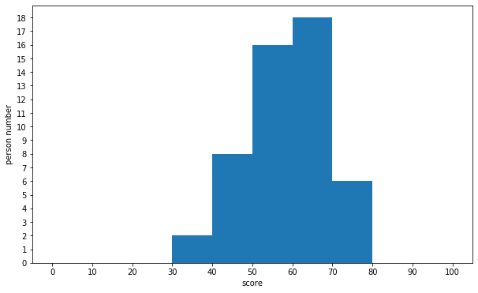

```python
# 캔버스를 생성
# figsize로 가로・세로 크기를 지정
fig = plt.figure( figsize = ( 10, 6 ) )
# 켄버스 위에 그래프를 그리기 위한 영역을 지정
# 인수는 영역을 1×1개 지정、하나의 영역에 그린다는 것을 의미
ax = fig.add_subplot( 111 )

# 계급수를 10으로 하여 히스토그램을 그림
freq, _, _ = ax.hist( english_scores, bins = 10, range = ( 0, 100 ) )
# X축에 레이블 부여
ax.set_xlabel( 'score' )
# Y축에 레이블 부여
ax.set_ylabel( 'person number' )
# X축을 0, 10, 20, ..., 100 눈금으로 구분
ax.set_xticks( np.linspace( 0, 100, 10 + 1 ) )
# Y축을 0, 1, 2, ...의 눈금으로 구분
ax.set_yticks( np.arange( 0, freq.max() + 1 ) )
# 그래프 표시
plt.show()
```

- 계급수를 늘리면 더 세부적인 데이터의 분포를 볼 수 있다.
- 계급수를 25, 즉 계급폭을 4점으로 하여 히스토그램을 출력해본다.

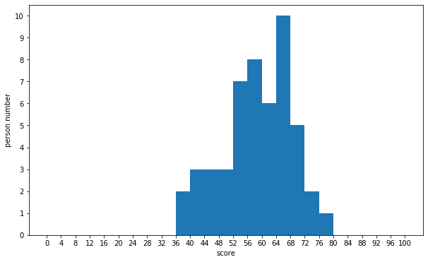

```python
fig = plt.figure( figsize = ( 10, 6 ) )
ax = fig.add_subplot( 111 )

freq, _ , _ = ax.hist( english_scores, bins = 25, range = ( 0, 100 ) )
ax.set_xlabel( 'score' )
ax.set_ylabel( 'person number' )
ax.set_xticks( np.linspace( 0, 100, 25 + 1 ) )
ax.set_yticks( np.arange( 0, freq.max() + 1 ) )
plt.show()
```

- 계급폭을 변경하니 히스토그램의 모양이 크게 변하였다.
- 도수분포표와 히스토그램은 계급수에 따라 모양이 크게 변하기 때문에, 데이터에 따라 적절한 값으로 설정하는 것이 중요하다.

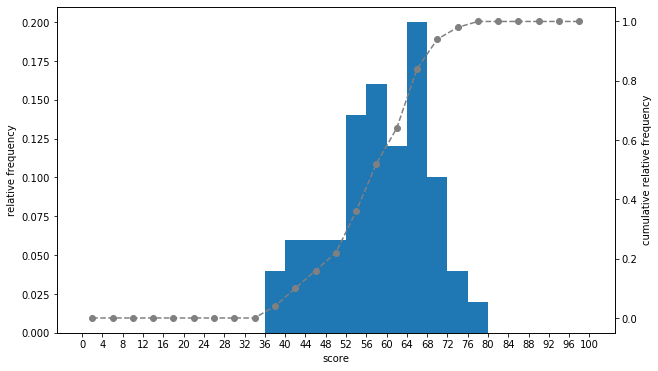

```python
# 상대도수의 히스토그램을 누적상대도수의 꺽은선 그래프와 함께 그린다.
fig = plt.figure( figsize = ( 10, 6 ) )
ax1 = fig.add_subplot( 111 )
# Y축의 스케일이 다른 그래프를 ax1과 동일한 영역에 생성
ax2 = ax1.twinx()

# 상대도수의 히스토그램으로 하기 위해서는, 도수를 데이터의 수로 나눌 필요가 있음
# 이것은 hist의 인수 weight를 지정하면 실현 가능
weights = np.ones_like( english_scores ) / len( english_scores )
rel_freq, _, _ = ax1.hist( english_scores, bins = 25,
                           range = ( 0, 100 ), weights = weights )

cum_rel_freq = np.cumsum( rel_freq )
class_value = [ ( i + ( i + 4 ) ) // 2 for i in range( 0, 100, 4 ) ]
# 꺾은선 그래프를 그림
# 인수 ls를 '--'로 하면 점선이 그려짐
# 인수 marker를 'o'으로 하면 데이터 점을 그람
# 인수 color를 'gray'로 하면 회색으로 지정
ax2.plot( class_value, cum_rel_freq,
          ls = '--', marker = 'o', color = 'gray' )
# 꺾은선 그래프의 눈금선을 제거
ax2.grid( visible = False )

ax1.set_xlabel( 'score' )
ax1.set_ylabel( 'relative frequency' )
ax2.set_ylabel( 'cumulative relative frequency' )
ax1.set_xticks( np.linspace( 0, 100, 25 + 1 ) )

plt.show()
```

### 상자그림

- 상자그림( boxplot )은 데이터의 산포도를 표현하는 그래프이다.
- 상자그림을 그리면 데이터의 분포와 이상값을 시각적으로 파악할 수 있다.
- 분위수 범위의 Q1, Q2, Q3, IQR을 사용한다.
- 상자는 Q1부터 Q3를 나타내고, 수염은 Q1 - 1.5IQR부터 Q3 + 1.5IQR을 나타낸다. 여기에 들어가지 않는 데이터는 이상값이 된다.
- 상자그림은 boxplot 메서드를 사용하여 그릴 수 있다.

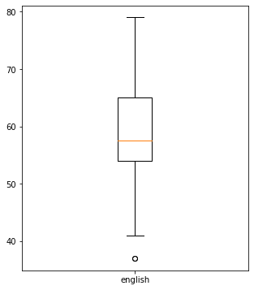

```python
fig = plt.figure( figsize = ( 5, 6 ) )
ax = fig.add_subplot( 111 )
ax.boxplot( english_scores, labels = [ 'english' ] )

plt.show()
```

# 2차원 데이터 정리

- 1차원 데이터 정리 방법으로는 평균과 분산이라는 지표, 히스토그램과 상자그림이라는 그래프롤 사용하였다.
- 학생 1명에 대해 두 과목이상의 점수가 대응되는 2차원 데이터 정리 방법으로는 데이터의 상관성을 파악할 수 있다.

```python
import numpy as np
import pandas as pd

%precision 3
pd.set_option( 'precision', 3 )
```

```python
df = pd.read_csv( './scores_em.csv', index_col = 'student number' )
df
```

| student number | english | mathematics |
| --- | --- | --- |
| 1 | 42 | 65 |
| 2 | 69 | 80 |
| 3 | 56 | 63 |
| 4 | 41 | 63 |
| 5 | 57 | 76 |
| 6 | 48 | 60 |
| 7 | 65 | 81 |
| 8 | 49 | 66 |
| 9 | 65 | 78 |
| 10 | 58 | 82 |
| 11 | 70 | 94 |
| 12 | 47 | 75 |
| 13 | 51 | 70 |
| 14 | 64 | 77 |
| 15 | 62 | 84 |
| 16 | 70 | 84 |
| 17 | 71 | 82 |
| 18 | 68 | 85 |
| 19 | 73 | 90 |
| 20 | 37 | 70 |
| 21 | 65 | 78 |
| 22 | 65 | 93 |
| 23 | 61 | 77 |
| 24 | 52 | 88 |
| 25 | 57 | 82 |
| 26 | 57 | 76 |
| 27 | 75 | 87 |
| 28 | 61 | 84 |
| 29 | 47 | 77 |
| 30 | 54 | 82 |
| 31 | 66 | 91 |
| 32 | 54 | 75 |
| 33 | 54 | 76 |
| 34 | 42 | 78 |
| 35 | 37 | 57 |
| 36 | 79 | 89 |
| 37 | 56 | 83 |
| 38 | 62 | 69 |
| 39 | 62 | 86 |
| 40 | 55 | 81 |
| 41 | 63 | 81 |
| 42 | 57 | 80 |
| 43 | 57 | 79 |
| 44 | 67 | 87 |
| 45 | 55 | 84 |
| 46 | 45 | 71 |
| 47 | 66 | 80 |
| 48 | 55 | 77 |
| 49 | 64 | 83 |
| 50 | 66 | 88 |

```python
en_scores = np.array( df[ 'english' ] )[ :10 ]
ma_scores = np.array( df[ 'mathematics' ] )[ :10 ]

scores_df = pd.DataFrame( { 'english': en_scores,
                            'mathematics': ma_scores },
                          index = pd.Index( [ 'A', 'B', 'C', 'D', 'E',
                                              'F', 'G', 'H', 'I', 'J'],
                                              name = 'student' ) )
scores_df
```

| student | english | mathematics |
| --- | --- | --- |
| A | 42 | 65 |
| B | 69 | 80 |
| C | 56 | 63 |
| D | 41 | 63 |
| E | 57 | 76 |
| F | 48 | 60 |
| G | 65 | 81 |
| H | 49 | 66 |
| I | 65 | 78 |
| J | 58 | 82 |

## 두 데이터 사이의 관계를 나타내는 지표

- 영어 점수가 높은 학생일수록 수학 점수도 높은 경향이 있다면, 영어 점수와 수학 점수는 양의 상관관계에 있다고 한다.
- 영어 점수가 높은 학생일수록 수학 점수가 낮은 경향이 있다면, 영어 점수와 수학 점수는 음의 상관관계에 있다고 한다.
- 어느 쪽에도 해당하지 않고 영어 점수가 수학 점수에 직접적으로 영향을 미치지 않을 때, 영어 점수와 수학 점수는 무상관이다.

### 공분산

- 양의 상관관계에 있다고 생각되는 데이터의 관계성을 수치화할 때 사용, 공분산은 분산에 가까운 지표
- 공분산이 분산과 다른 점은, 분산은 항상 양의 값을 갖게 되지만 공분산에서는 음의 값과 양의 값을 가질 수 있다.
- 공분산이 양의 값이면 면적이 양의 값이 되는 데이터가 많다는 뜻이므로 양의 상관관계에 있고, 반대로 공분산이 음의 값이면 면적이 의의 값이 되는 데이터가 많다는 뜻이므로 음의 상관관계에 있다고 할 수 있다.
- 공분산이 0에 가까우면 무상관을 나타낸다.

```python
# DataFrame으로 공분산 계산
summary_df = scores_df.copy()
summary_df[ 'english_deviation' ] =\
    summary_df[ 'english' ] - summary_df[ 'english' ].mean()
summary_df[ 'mathematics_deviation' ] =\
    summary_df[ 'mathematics' ] - summary_df[ 'mathematics' ].mean()
summary_df[ 'product of deviations' ] =\
    summary_df[ 'english_deviation' ] * summary_df[ 'mathematics_deviation' ]
summary_df
```

| student | english | mathematics | english_deviation | mathematics_deviation | product of deviations |
| --- | --- | --- | --- | --- | --- |
| A | 42 | 65 | -13.0 | -6.4 | 83.2 |
| B | 69 | 80 | 14.0 | 8.6 | 120.4 |
| C | 56 | 63 | 1.0 | -8.4 | -8.4 |
| D | 41 | 63 | -14.0 | -8.4 | 117.6 |
| E | 57 | 76 | 2.0 | 4.6 | 9.2 |
| F | 48 | 60 | -7.0 | -11.4 | 79.8 |
| G | 65 | 81 | 10.0 | 9.6 | 96.0 |
| H | 49 | 66 | -6.0 | -5.4 | 32.4 |
| I | 65 | 78 | 10.0 | 6.6 | 66.0 |
| J | 58 | 82 | 3.0 | 10.6 | 31.8 |

```python
summary_df[ 'product of deviations' ].mean()
```

```
62.800
```

- 영어 점수와 수학 점수는 양의 상관관계에 있다고 할 수 있다.
- 수식으로 정리해 보면, 공분산은 흔히 \begin{equation*}S_{xy}\end{equation*}로 표기한다.
- 변수 x와 변수 y의 공분산임을 나타낸다.
- 위의 예에서 변수 x는 영어, 변수 y는 수학에 대응된다고 볼 수 있다.
- 공분산은 변수 x와 변수 y를 서로 바꾸어도 값이 변하지 않는다.

\begin{equation*} S_{xy} = \frac{1}{n}\sum_{i=1}^{n}(x_i - \overline{x})(y_i - \overline{y}) = \frac{1}{n}\{(x_1 - \overline{x})(y_1 - \overline{y}) + (x_2 - \overline{x})(y_2 - \overline{y}) + ... + (x_n - \overline{x})(y_n - \overline{y})\} \end{equation*}

- NumPy의 경우, 공분산은 cov 함수로 구할 수 있다.
- 반환값은 공분산값이 아닌 공분산 행렬( covariance matrix ) 또는 분산공분산 행렬( variance-covariance matrix )이라고 부르는 행렬이다.

```python
cov_mat = np.cov( en_scores, ma_scores, ddof = 0 )
cov_mat
```

```
array([[86.  , 62.8 ],
       [62.8 , 68.44]])
```

- 이 행렬의 첫 번째 행과 첫 번째 열이 첫 번째 인수인 영어, 두 번째 행과 두 번째 열이 두 번째 인수인 수학에 각각 대응하고, 이것들을 교차하여 1행 2열의 성분과 2행 1열의 성분이 영어와 수학의 공분산에 해당한다.
- cov_mat[ 0, 1 ] 요소와 cov_mat[ 1, 0 ] 요소가 공분산이 된다.

```python
cov_mat[ 0, 1 ], cov_mat[ 1, 0 ]
```

```
(62.800000000000004, 62.800000000000004)
```

- cov_mat[ 0, 0 ] 요소는 영어와 영어의 공분산이 된다.
- 동일한 변수들의 공분산은 해당 변수의 분산과 같다.
- cov_mat[ 0, 0 ] 요소는 영어의 분산, cov_mat[ 1, 1 ] 요소는 수학의 분산이 된다.

```python
cov_mat[ 0, 0 ], cov_mat[ 1, 1 ]
```

```
(86.0, 68.44000000000001)
```

```python
# 영어와 수학의 분산
np.var( en_scores, ddof = 0 ), np.var( ma_scores, ddof = 0 )
```

```
(86.0, 68.44000000000001)
```

- 분산과 일치함을 확인할 수 있다.
- DataFrame에도 cov 메서드가 있지만 var 메서드와 달리 ddof 인수를 취하지 않고 불편분산만 계산할 수 있다.

### 상관계수

- 공분산을 계산하여 데이터의 상관관계를 표현했다.
- 시험 점수들 간에 공분산은 ( 점수 X 점수 )라는 단위를 사용한다. 학생 키와 시험 점수의 상관관계를 본다면, 공분산은 ( cm X 점수 )라는 단위가 된다.
- 분산의 경우와 마찬가지로 이런 단위는 직감적으로 이해하기 어렵다.
- 단위에 의존하지 않는 상관은 나타내는 지표가 필요하다. 공분산은 각 데이터의 단위를 곱한 것이므로, 공분산을 각 데이터의 표준편차로 나누어 단위에 의존하지 않는 지표를 정의할 수 있다.

\begin{equation*} r_{xy} = \frac{S_{xy}}{S_{x}S{y}} = \frac{1}{n}\sum_{i=1}^{n}(\frac{x_i - \overline{x}}{S_{x}})(\frac{y_i - \overline{y}}{S_{y}}) \end{equation*}

- 이와 같이 정의된 지표 \begin{equation*}r_{xy}\end{equation*}를 상관계수( correlation coefficient )라고 한다.
- 상관계수는 반드시 -1에서 1사이의 값을 취하고,
- 데이터가 양의 상관관계에 놓여 있을수록 1에 가까워지고,
- 음의 상관관계에 놓여 있을수록 -1에 가까워진다.
- 무상관이면 0이 된다.
- *상관계수가 -1일 때와 1일 때에는 데이터가 완전히 직선상에 놓인다.*

```python
# 영어 점수와 수학 점수의 상관계수
np.cov( en_scores, ma_scores, ddof = 0 )[ 0, 1 ] /( np.std( en_scores ) * np.std( ma_scores ) )
```

```
0.8185692341186713
```

- 상관계수는 0.818로 1에 가까운 값이다.
- '상관계수가 어느 정도이면 상관이 있다'라는 명확한 기준은 없지만, 상관계수가 0.8인 데이터는 강한 상관을 가지고 있다. 이로부터 영어 점수와 수학 점수에는 강한 양의 상관이 있음을 알수 있다.
- NumPy의 경우, 상관계수는 corrcoef 함수로 계산할 수 있다. 다만, 반환값은 공분산의 경우와 마찬가지로 상관행렬( correlation matrix )이라 부르는 행렬이다.

```python
np.corrcoef( en_scores, ma_scores )
```

```
array([[1.   , 0.819],
       [0.819, 1.   ]])
```

- 상관행령의 [ 0, 1 ] 요소와 [ 1, 0 ] 요소가 영어와 수학의 상관계수에 대응하고 있다. 나머지 [ 0, 0 ] 요소는 영어와 영어의 상관계수, [ 1, 1 ] 요소는 수학과 수학의 상관계수에 대응하므로 1이다.
- DataFrame의 경우, corr 메서드와 동일한 결과를 얻을 수 있다.

```python
scores_df.corr()
```

|  | english | mathematics |
| --- | --- | --- |
| english | 1.000 | 0.819 |
| mathematics | 0.819 | 1.000 |

## 2차원 데이터의 시각화

- 2차원 데이터를 시각화할 때는 산점도( scatter plot )가 매우 편리하다.
- 산점도와 함께 데이터의 관계를 표현하는 직선인 회귀직선과 히스토그램의 2차원 버전인 히트맵도 편리하다.

```python
import matplotlib.pyplot as plt

%matplotlib inline
```

### 산점도

- Matplotlib에서는 scatter 메서드를 사용하여 산점도를 그릴 수 있다.
- scatter의 첫 번째 인수가 x 축의 데이터, 두 번째 인수가 y축의 데이터이다.

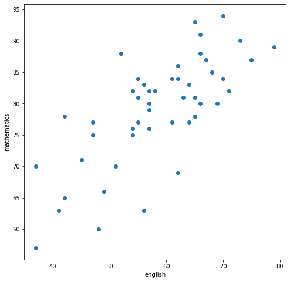

```python
english_scores = np.array( df[ 'english' ] )
math_scores = np.array( df[ 'mathematics' ] )

fig = plt.figure( figsize = ( 8, 8 ) )
ax = fig.add_subplot( 111 )
# 산점도
ax.scatter( english_scores, math_scores )
ax.set_xlabel( 'english' )
ax.set_ylabel( 'mathematics' )

plt.show()
```

- 산점도를 통해 영어 점수가 높은 사람일수록 수학 점수도 높은 경향이 있다는 것을 알 수 있다.

### 회귀직선

- 회귀직선( regression line )은 두 데이터 사이의 관계를 더욱 잘 나타내는 직선이다.
- Matplotlib에는 회귀직선을 직접 그리는 메서드가 없기 때문에 NumPy를 사용하여 회귀직선을 구한다.
- np.polyfit 함수와 np.ploy1d 함수를 사용하여 영어 점수를 x, 수학 점수를 y로 했을 때 회귀직선 y = b + WX를 구할 수 있다.
- 회귀직선이 준비되었으면, plot 메서드로 그리기만 하면 된다.

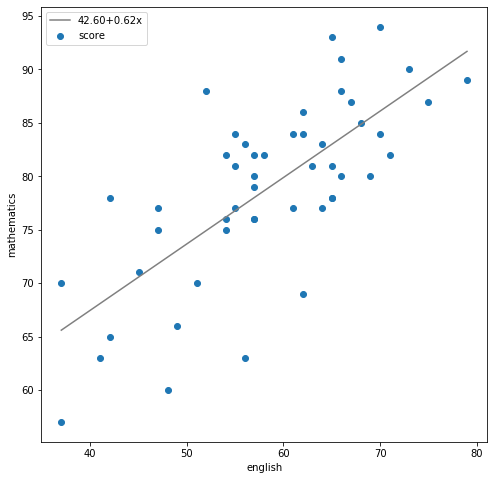

```python
# 계수 b와 W를 구한다
poly_fit = np.polyfit( english_scores, math_scores, 1 )
# b + WX를 반환하는 함수를 작성
poly_1d = np.poly1d( poly_fit )
# 직선을 그리기 위해 x좌표를 생성
xs = np.linspace( english_scores.min(), english_scores.max() )
# xs에 대응하는 y좌표를 구한다
ys = poly_1d( xs )

fig = plt.figure( figsize = ( 8, 8 ) )
ax = fig.add_subplot( 111 )
ax.set_xlabel( 'english' )
ax.set_ylabel( 'mathematics' )
ax.scatter( english_scores, math_scores, label = 'score' )
ax.plot(xs, ys, color='gray',
        label=f'{poly_fit[1]:.2f}+{poly_fit[0]:.2f}x')
# 범례의 표시
ax.legend( loc = 'upper left' )

plt.show()
```

### 히트맵

- 히트맵( heat map )은 히스토그램의 2차원 버전으로 색을 이용해 표현할 수 있는 그래프이다.
- hist2d 메서드로 작성할 수 있다. 인수도 hist 메서드와 거의 동일하다.
- 아래 예는 영어 점수가 35점부터 80점까지 5점 간격, 수학 점수가 55점부터 95점까지 5점 간격이 되도록 bins와 range를 지정했다.
- 색이 진한 영역일수록 많은 학생이 분포되어 있음을 나타낸다. 영어 점수 55 ~ 60점, 수학 점수 80 ~ 85점인 학생이 가장 많다는 것을 알 수 있다.

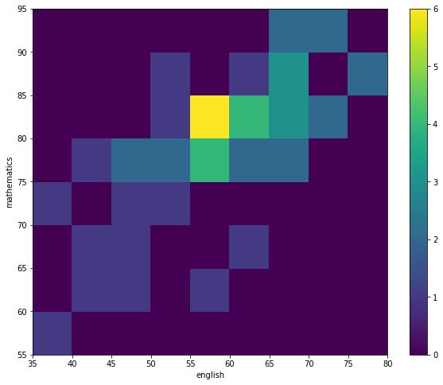

```python
fig = plt.figure( figsize = ( 10, 8 ) )
ax = fig.add_subplot( 111 )

c = ax.hist2d( english_scores, math_scores,
               bins = [ 9, 8 ], range = [ ( 35, 80 ), ( 55, 95 ) ] )
ax.set_xlabel( 'english' )
ax.set_ylabel( 'mathematics' )
ax.set_xticks( c[ 1 ] )
ax.set_yticks( c[ 2 ] )
# 컬러 바의 표시
fig.colorbar( c[ 3 ], ax = ax )

plt.show()
```

## 앤스컴의 예

- 앤스컴 콰르텟( Anscombe's quartet )은 평균, 표본분산, 상관, 선형회귀선, 결정계수 등의 기술통계량은 동일하지만, 분포나 그래프를 이용하여 시각화하면 전혀 다른 4개의 데이터 세트를 의미한다.
- 1973년 통계학자 프란시스 앤스컴( Francis Anscombe )이 데이터 분석 전 시각화의 중요성을 보여주기 위해 만들었다.

```python
# npy 형식으로 저장된 NumPy array를 읽어들인다
anscombe_data = np.load( 'anscombe.npy' )
print( anscombe_data.shape )
anscombe_data[ 0 ]
```

```
(4, 11, 2)
```

```
array([[10.  ,  8.04],
       [ 8.  ,  6.95],
       [13.  ,  7.58],
       [ 9.  ,  8.81],
       [11.  ,  8.33],
       [14.  ,  9.96],
       [ 6.  ,  7.24],
       [ 4.  ,  4.26],
       [12.  , 10.84],
       [ 7.  ,  4.82],
       [ 5.  ,  5.68]])
```

```python
# 각 데이터의 평균, 분산, 상관계수, 회귀직선을 계산하여 DataFrame 생성
stats_df = pd.DataFrame( index = [ 'X_mean', 'X_variance', 'Y_mean',
                                   'Y_variance', 'X&Y_correlation',
                                   'X&Y_regression line' ] )
for i, data in enumerate( anscombe_data ):
    dataX = data[ :, 0 ]
    dataY = data[ :, 1 ]
    poly_fit = np.polyfit( dataX, dataY, 1 )
    stats_df[ f'data{i+1}' ] =\
        [ f'{np.mean(dataX):.2f}',
          f'{np.var(dataX):.2f}',
          f'{np.mean(dataY):.2f}',
          f'{np.var(dataY):.2f}',
          f'{np.corrcoef(dataX, dataY)[0, 1]:.2f}',
          f'{poly_fit[1]:.2f}+{poly_fit[0]:.2f}x' ]
stats_df
```

|  | data1 | data2 | data3 | data4 |
| --- | --- | --- | --- | --- |
| X_mean | 9.00 | 9.00 | 9.00 | 9.00 |
| X_variance | 10.00 | 10.00 | 10.00 | 10.00 |
| Y_mean | 7.50 | 7.50 | 7.50 | 7.50 |
| Y_variance | 3.75 | 3.75 | 3.75 | 3.75 |
| X&Y_correlation | 0.82 | 0.82 | 0.82 | 0.82 |
| X&Y_regression line | 3.00+0.50x | 3.00+0.50x | 3.00+0.50x | 3.00+0.50x |

- 모든 데이터가 평균부터 회귀직선 식까지 전부 일치하다. 결국 지표상으로 보면 이 네 가지 데이터는 모두 동일하다.
- 네 가지 데이터가 완전히 동일한지 확인하기 위해 산점도를 그려본다.

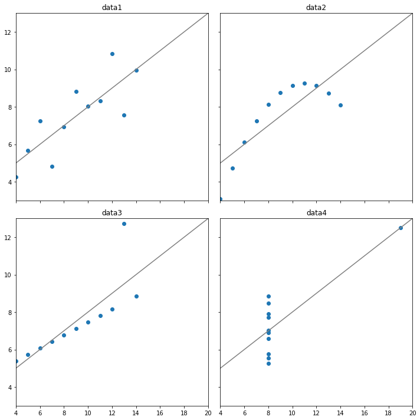

```python
# 그래프를 그리기 위한 영역을 2x2개 생성
fig, axes = plt.subplots( nrows = 2, ncols = 2, figsize = ( 10, 10 ),
                          sharex = True, sharey = True )

xs = np.linspace( 0, 30, 100 )
for i, data in enumerate( anscombe_data ):
    poly_fit = np.polyfit( data[ :,0 ], data[ :,1 ], 1 )
    poly_1d = np.poly1d( poly_fit )
    ys = poly_1d( xs )
    # 그리는 영역을 선택
    ax = axes[ i // 2, i % 2 ]
    ax.set_xlim( [ 4, 20 ] )
    ax.set_ylim( [ 3, 13 ] )
    # 타이틀을 부여
    ax.set_title( f'data{i+1}' )
    ax.scatter( data[ :,0 ], data[ :,1 ] )
    ax.plot( xs, ys, color = 'gray' )

# 그래프 사이의 간격을 좁힘
plt.tight_layout()

plt.show()
```

- 시각화 결과를 통해 볼 수 있듯이, 이들 데이터는 전혀 다른 분포를 띠고 있다.
- 평균이나 분산이라는 지표가 많은 의미를 갖지만, 이러한 지표들을 과신하면 안 된다.
- 앤스컴의 예는 데이터를 분석할 때는 가능하면 시각화를 하여야 한다는 것을 알려준다.